# Causality slides

## Przyczynowość i jej wykrywanie

*Wiktor Soral 15.06.2016*

Często zależy nam na stwierdzeniu kierunku przyczynowości: a czy b?

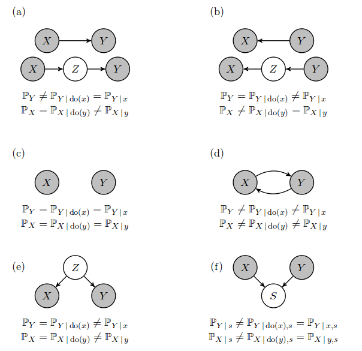

```python
Image(filename='diagrams.png', width=600)
```

## Możliwe opcje

- przeprowadzić eksperyment, a najlepiej dwa - nie zawsze jest to możliwe
- przeprowadzić badanie podłużne - kosztowne
- dobrać i porównać ze sobą najbardziej podobne przypadki - problem z niemierzonymi zmiennymi
- wykorzystać aparat matematyczny, np. DAG (directed acyclic graphs)
- **zastanowić się czego oczekiwalibyśmy, jeżeli jedna zmienna wpływa na drugą**

## Przykład

Wyobraźmy sobie 2 zmienne pozostające ze sobą w pewnej zależności. Prosty wykres rozrzutu pozwoli nam zobrazować tą zależność.

$y = 2 + 0.5x - 0.1x^2 + 0.01x^3 + e$

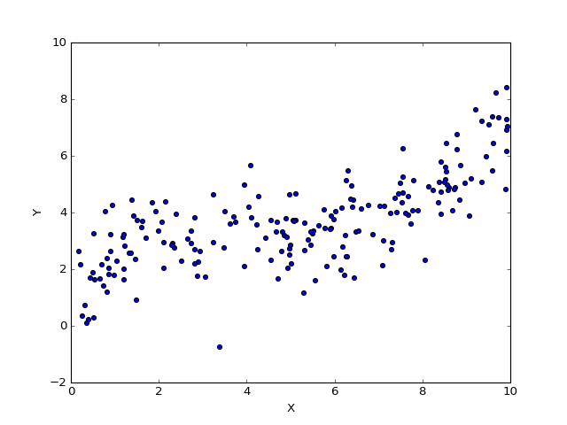

```
(0, 10)
```

```python
plt.scatter(x,y)
plt.xlabel("X");plt.ylabel("Y");plt.xlim(0,10)
```

## O czym mówi nam wykres rozrzutu?

Oczywiście taki wykres rozrzutu nie mówi nam nic o charakterze przyczynowym relacji pomiędzy tymi zmiennymi.

Zakładając jednak, że prawdziwe jest jedno z 2:

- X --> Y
- Y --> X

możemy oczekiwać pewnej asymetrii w rozkładzie obu zmiennych. Wynika to z faktu, że:

$y = f(x) + \epsilon$

gdzie

$\epsilon \sim N(0,\sigma)$

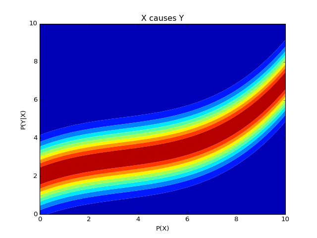

```python
CS = plt.contourf(X,Y,Z, 10, antialiased= True)
plt.xlabel("P(X)"); plt.ylabel("P(Y|X)"); plt.title("X causes Y")
```

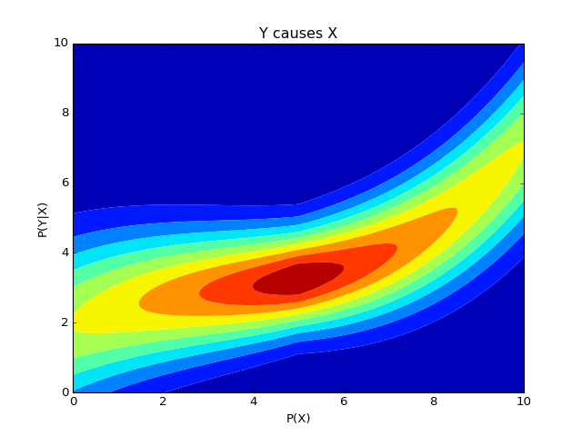

```python
plt.contourf(X,Y,Z2, 10, antialiased= True)
plt.xlabel("P(X)");plt.ylabel("P(Y|X)");plt.title("Y causes X")
```

## Proponowany algorytm

1. Podziel zbiór danych X i Y na podzbiór treningowy i testowy
2. Dopasuj modele: Y na X i X na Y na danych treningowych
3. Przy użyciu funkcji obliczonych w 2 oblicz reszty regresji na danych testowych
4. Oblicz wskaźniki zależności pomiędzy predyktorami a resztami: C(X,reszty od Y) i C(Y, reszty od X)
5. Przyjmij, że model, w którym reszty są (w większym stopniu) niezależne od predyktorów - o niższym C - jest przykładem modelu z addytywnym szumem

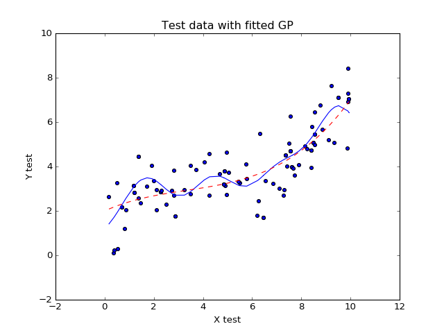

```python
plt.scatter(x_test, y_test)
plt.plot(x_test[np.argsort(x_test)], outXcY['y2'][np.argsort(x_test)])
plt.plot(x_test[np.argsort(x_test)], zaleznosc(x_test[np.argsort(x_test)]), 'r--')
plt.xlabel("X test"); plt.ylabel("Y test"); plt.title("Test data with fitted GP")
```

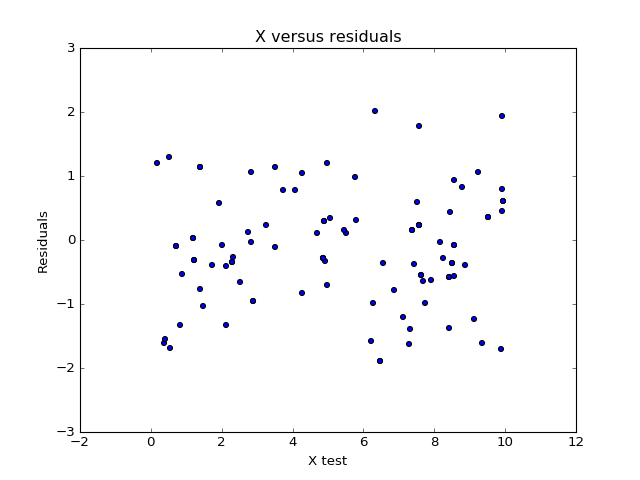

```python
plt.scatter(x_test, (y_test - outXcY['y2']))
plt.xlabel("X test"); plt.ylabel("Residuals"); plt.title("X versus residuals")
```

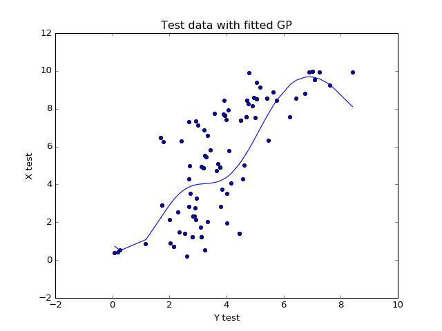

```python
plt.scatter(y_test, x_test)
plt.plot(y_test[np.argsort(y_test)], outYcX['y2'][np.argsort(y_test)])
plt.xlabel("Y test"); plt.ylabel("X test"); plt.title("Test data with fitted GP")
```

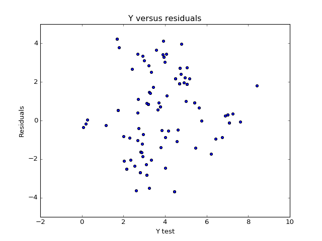

```python
plt.scatter(y_test, (x_test - outYcX['y2']))
plt.xlabel("Y test"); plt.ylabel("Residuals"); plt.title("Y versus residuals")
```

## Jak sprawdzić niezależność dwóch zmiennych losowych?

- współczynnik korelacji - ale: mierzy tylko zależność liniową
- szereg innych miar
- HSIC - Hilbert-Schmidt Independence Criterion

```python
print "HSIC dla modelu X -> Y:", round(resXcY*10e9, 2)
print "HSIC dla modelu Y -> X:", round(resYcX*10e9, 2)
```

```
HSIC dla modelu X -> Y: 25.21
HSIC dla modelu Y -> X: 221.95
```

## Wyzwania

1. Czy to faktycznie działa?
2. Czy inni dadzą się przekonać, że to działa?
3. Czy to działa również na danych z badań społecznych i behawioralnych (np. wszechobecny problem 3 zmiennej)?
4. Czy da się zrobić tak, żeby to faktycznie było użyteczne?